# LAB5

## directed network

```r
samplk3
```

```
##  Network attributes:
##   vertices = 18
##   directed = TRUE
##   hyper = FALSE
##   loops = FALSE
##   multiple = FALSE
##   bipartite = FALSE
##   total edges= 56
##     missing edges= 0
##     non-missing edges= 56
##
##  Vertex attribute names:
##     cloisterville group vertex.names
##
## No edge attributes
```

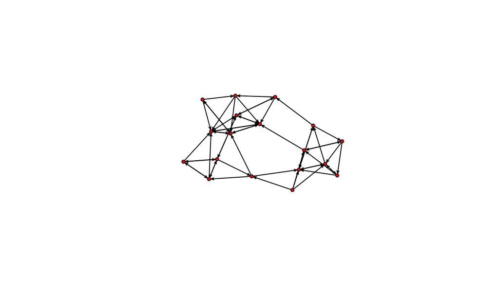

```r
set.seed(1)
plot(samplk3)
```

## Include `mutual`

```r
sampmodel.01 <- ergm(samplk3~edges+mutual)
```

```
## Starting maximum pseudolikelihood estimation (MPLE):
```

```
## Evaluating the predictor and response matrix.
```

```
## Maximizing the pseudolikelihood.
```

```
## Finished MPLE.
```

```
## Starting Monte Carlo maximum likelihood estimation (MCMLE):
```

```
## Iteration 1 of at most 20:
```

```
## Optimizing with step length 1.
```

```
## The log-likelihood improved by 0.0002847.
```

```
## Step length converged once. Increasing MCMC sample size.
```

```
## Iteration 2 of at most 20:
```

```
## Optimizing with step length 1.
```

```
## The log-likelihood improved by 0.001122.
```

```
## Step length converged twice. Stopping.
```

```
## Finished MCMLE.
```

```
## Evaluating log-likelihood at the estimate. Using 20 bridges: 1 2 3 4 5 6 7 8 9 10 11 12 13 14 15 16 17 18 19 20 .
## This model was fit using MCMC.  To examine model diagnostics and check for degeneracy, use the mcmc.diagnostics() function.
```

```r
summary(sampmodel.01)
```

```
##
## ==========================
## Summary of model fit
## ==========================
##
## Formula:   samplk3 ~ edges + mutual
##
## Iterations:  2 out of 20
##
## Monte Carlo MLE Results:
##        Estimate Std. Error MCMC % z value Pr(>|z|)
## edges   -2.1505     0.2152      0  -9.993   <1e-04 ***
## mutual   2.2849     0.4684      0   4.878   <1e-04 ***
## ---
## Signif. codes:  0 '***' 0.001 '**' 0.01 '*' 0.05 '.' 0.1 ' ' 1
##
##      Null Deviance: 424.2  on 306  degrees of freedom
##  Residual Deviance: 268.0  on 304  degrees of freedom
##
## AIC: 272    BIC: 279.5    (Smaller is better.)
```

Strong mutual effect.

## Include `sender`, `receiver`, `mutual`

p1 model

```r
sampmodel.02 <- ergm(samplk3~ edges + sender + receiver + mutual)
```

```
## Observed statistic(s) receiver10 are at their smallest attainable values. Their coefficients will be fixed at -Inf.
```

```
## Starting maximum pseudolikelihood estimation (MPLE):
```

```
## Evaluating the predictor and response matrix.
```

```
## Maximizing the pseudolikelihood.
```

```
## Finished MPLE.
```

```
## Starting Monte Carlo maximum likelihood estimation (MCMLE):
```

```
## Iteration 1 of at most 20:
```

```
## Optimizing with step length 1.
```

```
## The log-likelihood improved by 1.081.
```

```
## Step length converged once. Increasing MCMC sample size.
```

```
## Iteration 2 of at most 20:
```

```
## Optimizing with step length 1.
```

```
## The log-likelihood improved by 0.08992.
```

```
## Step length converged twice. Stopping.
```

```
## Finished MCMLE.
```

```
## Evaluating log-likelihood at the estimate. Using 20 bridges: 1 2 3 4 5 6 7 8 9 10 11 12 13 14 15 16 17 18 19 20 .
## This model was fit using MCMC.  To examine model diagnostics and check for degeneracy, use the mcmc.diagnostics() function.
```

```r
summary(sampmodel.02)
```

```
##
## ==========================
## Summary of model fit
## ==========================
##
## Formula:   samplk3 ~ edges + sender + receiver + mutual
##
## Iterations:  2 out of 20
##
## Monte Carlo MLE Results:
##             Estimate Std. Error MCMC % z value Pr(>|z|)
## edges      -2.315741   0.796090      0  -2.909  0.00363 **
## sender2    -0.438628   1.092996      0  -0.401  0.68819
## sender3     0.776450   1.093259      0   0.710  0.47757
## sender4    -0.008577   1.115291      0  -0.008  0.99386
## sender5    -0.452058   1.134888      0  -0.398  0.69039
## sender6     0.502989   1.095639      0   0.459  0.64617
## sender7    -0.252892   1.103350      0  -0.229  0.81871
## sender8     0.529555   1.111692      0   0.476  0.63382
## sender9     0.005037   1.122952      0   0.004  0.99642
## sender10    1.457053   1.055864      0   1.380  0.16760
## sender11    0.534553   1.100976      0   0.486  0.62730
## sender12   -0.446945   1.125660      0  -0.397  0.69133
## sender13    0.530122   1.107423      0   0.479  0.63215
## sender14    0.529945   1.117297      0   0.474  0.63528
## sender15    0.508301   1.123175      0   0.453  0.65087
## sender16    0.793735   1.081730      0   0.734  0.46309
## sender17    0.526922   1.107444      0   0.476  0.63422
## sender18    0.235750   1.103263      0   0.214  0.83079
## receiver2   0.772420   0.896048      0   0.862  0.38867
## receiver3  -0.739738   0.996962      0  -0.742  0.45809
## receiver4   0.017002   0.951789      0   0.018  0.98575
## receiver5   0.766819   0.911852      0   0.841  0.40038
## receiver6  -1.087262   1.114647      0  -0.975  0.32935
## receiver7   0.412868   0.901948      0   0.458  0.64713
## receiver8  -1.111177   1.098415      0  -1.012  0.31172
## receiver9  -0.001184   0.951954      0  -0.001  0.99901
## receiver10      -Inf   0.000000      0    -Inf  < 1e-04 ***
## receiver11 -1.089252   1.082136      0  -1.007  0.31414
## receiver12  0.755936   0.907398      0   0.833  0.40480
## receiver13 -1.107780   1.098538      0  -1.008  0.31326
## receiver14 -1.092423   1.110361      0  -0.984  0.32519
## receiver15 -1.111820   1.099080      0  -1.012  0.31173
## receiver16 -2.004070   1.347086      0  -1.488  0.13683
## receiver17 -1.096807   1.109898      0  -0.988  0.32305
## receiver18 -0.480288   1.012901      0  -0.474  0.63538
## mutual      3.153694   0.636817      0   4.952  < 1e-04 ***
## ---
## Signif. codes:  0 '***' 0.001 '**' 0.01 '*' 0.05 '.' 0.1 ' ' 1
##
##      Null Deviance: 424.2  on 306  degrees of freedom
##  Residual Deviance:   NaN  on 270  degrees of freedom
##
## AIC: NaN    BIC: NaN    (Smaller is better.)
##
##  Warning: The following terms have infinite coefficient estimates:
##   receiver10
```

```r
degree(samplk3,cmode = "indegree")
```

```
##  [1] 4 6 3 4 6 2 5 2 4 0 2 6 2 2 2 1 2 3
```

## Other `ergm-terms`

Details of other `ergm-terms` see https://www.jstatsoft.org/article/view/v024i04.

## Missing edges

Make sure to set missing edges as `NA`: probability of an edge in the observed sample.

```r
missnet=flomarriage
missnet[1,2]=missnet[2,4]=missnet[5,6]=NA # originally are 0
summary(ergm(missnet~edges))
```

```
## Starting maximum pseudolikelihood estimation (MPLE):
```

```
## Evaluating the predictor and response matrix.
```

```
## Maximizing the pseudolikelihood.
```

```
## Finished MPLE.
```

```
## Stopping at the initial estimate.
```

```
## Evaluating log-likelihood at the estimate.
```

```
##
## ==========================
## Summary of model fit
## ==========================
##
## Formula:   missnet ~ edges
##
## Iterations:  5 out of 20
##
## Monte Carlo MLE Results:
##       Estimate Std. Error MCMC % z value Pr(>|z|)
## edges  -1.5790     0.2456      0   -6.43   <1e-04 ***
## ---
## Signif. codes:  0 '***' 0.001 '**' 0.01 '*' 0.05 '.' 0.1 ' ' 1
##
##      Null Deviance: 162.2  on 117  degrees of freedom
##  Residual Deviance: 107.0  on 116  degrees of freedom
##
## AIC: 109    BIC: 111.8    (Smaller is better.)
```

```r
summary(ergm(flomarriage~edges))
```

```
## Starting maximum pseudolikelihood estimation (MPLE):
## Evaluating the predictor and response matrix.
## Maximizing the pseudolikelihood.
## Finished MPLE.
## Stopping at the initial estimate.
## Evaluating log-likelihood at the estimate.
```

```
##
## ==========================
## Summary of model fit
## ==========================
##
## Formula:   flomarriage ~ edges
##
## Iterations:  5 out of 20
##
## Monte Carlo MLE Results:
##       Estimate Std. Error MCMC % z value Pr(>|z|)
## edges  -1.6094     0.2449      0  -6.571   <1e-04 ***
## ---
## Signif. codes:  0 '***' 0.001 '**' 0.01 '*' 0.05 '.' 0.1 ' ' 1
##
##      Null Deviance: 166.4  on 120  degrees of freedom
##  Residual Deviance: 108.1  on 119  degrees of freedom
##
## AIC: 110.1    BIC: 112.9    (Smaller is better.)
```

```r
#Set NA
1/(1+exp(-(-1.5790)))
```

```
## [1] 0.1709372
```

```r
20/(choose(16,2)-3)
```

```
## [1] 0.1709402
```

```r
#Set 0
1/(1+exp(-(-1.6094)))
```

```
## [1] 0.1666719
```

```r
20/(choose(16,2))
```

```
## [1] 0.1666667
```

## `simulate` netowrks from an ergm model fit

The ergm model defines a probability distibution across all networks of this size(#nodes fixed).

Use `simulate(ergm-model,nsim=n)` to get a list of networks

Use `summary` and functions that can be used to a list

```r
summary(flomodel.04)
```

```
##
## ==========================
## Summary of model fit
## ==========================
##
## Formula:   flomarriage ~ edges + absdiff("wealth")
##
## Iterations:  4 out of 20
##
## Monte Carlo MLE Results:
##                 Estimate Std. Error MCMC % z value Pr(>|z|)
## edges          -2.302042   0.401906      0  -5.728   <1e-04 ***
## absdiff.wealth  0.015519   0.006157      0   2.521   0.0117 *
## ---
## Signif. codes:  0 '***' 0.001 '**' 0.01 '*' 0.05 '.' 0.1 ' ' 1
##
##      Null Deviance: 166.4  on 120  degrees of freedom
##  Residual Deviance: 102.0  on 118  degrees of freedom
##
## AIC: 106    BIC: 111.5    (Smaller is better.)
```

```r
flomodel.04.sim <- simulate(flomodel.04, nsim=10,seed = 1)
class(flomodel.04.sim)
```

```
## [1] "network.list"
```

```r
summary(flomodel.04.sim)
```

```
## Number of Networks: 10
## Model: flomarriage ~ edges + absdiff("wealth")
## Reference: ~Bernoulli
## Constraints: ~.
## Parameters:
##          edges absdiff.wealth
##     -2.3020421      0.0155192
##
## Stored network statistics:
##       edges absdiff.wealth
##  [1,]    20           1070
##  [2,]    22           1170
##  [3,]    19            734
##  [4,]    18           1123
##  [5,]    18           1215
##  [6,]    15            697
##  [7,]    20           1165
##  [8,]    31           1577
##  [9,]    19           1138
## [10,]    22           1136
```

[output not shown]

```r
length(flomodel.04.sim)
```

```
## [1] 10
```

```r
flomodel.04.sim[[4]]
```

```
##  Network attributes:
##   vertices = 16
##   directed = FALSE
##   hyper = FALSE
##   loops = FALSE
##   multiple = FALSE
##   bipartite = FALSE
##   total edges= 18
##     missing edges= 0
##     non-missing edges= 18
##
##  Vertex attribute names:
##     priorates totalties vertex.names wealth
##
## No edge attributes
```

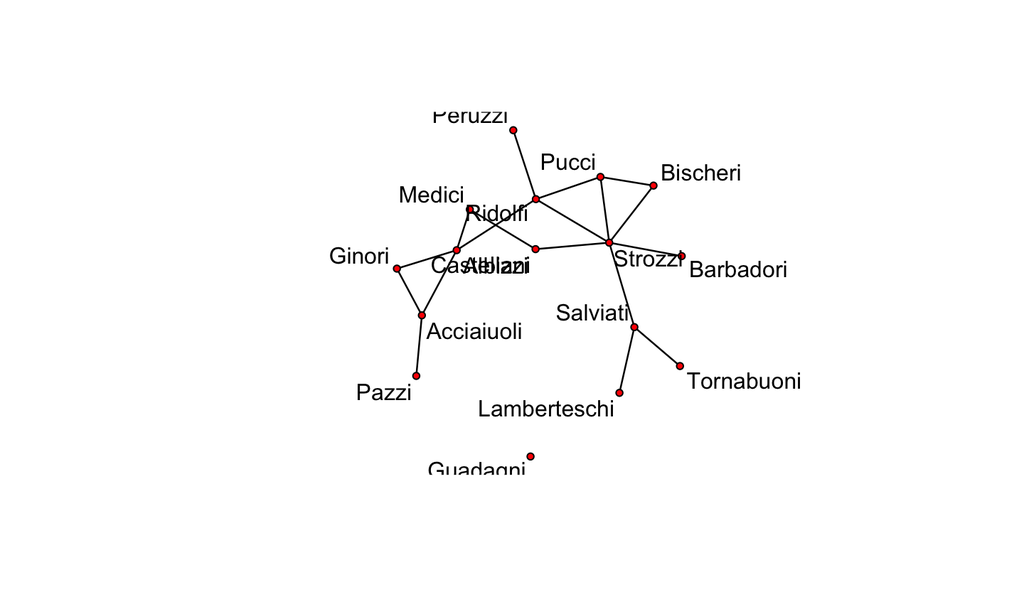

```r
plot(flomodel.04.sim[[4]], label= flomodel.04.sim[[4]] %v% "vertex.names")
```

```r
flomarriage
```

```
##  Network attributes:
##   vertices = 16
##   directed = FALSE
##   hyper = FALSE
##   loops = FALSE
##   multiple = FALSE
##   bipartite = FALSE
##   total edges= 20
##     missing edges= 0
##     non-missing edges= 20
##
##  Vertex attribute names:
##     priorates totalties vertex.names wealth
##
## No edge attributes
```

## `simulate` netowrks from an ergm model fit

- formula: Specify your own model
- `basis`: initial network for MC
- `control`: settings of MCMC

```r
basenet <- network(16,density=0.1,directed=FALSE)
g.sim <- simulate(flomarriage ~ edges + kstar(2), nsim=1000, coef=c(-1.8,0.03),
                  basis=basenet, control=control.simulate(MCMC.burnin=1000, MCMC.interval=10))
# MCMC.interval: Number of proposals between sampled statistics.
length(g.sim)
```

```
## [1] 1000
```

```r
?simulate.ergm
```

## Check the goodness of fit

- AIC,BIC; Deviance;
- Goodness of fit: `gof`
- MCMC diagnostics: `mcmc.diagnostics`

## `gof`

`gof(model~model+degree+esp+distance)`

Only four possible arguments for ergm-term:

- `model`: all the terms included in the model
- `degree`: degree (node level)
- `esp`: edgwise share partners (edge level)
- `distance`: geodesic distances (dyad level)

Draw samples from the specified model, calculate the MC p-value based on the distribution generated by the samples.

```r
flo.04.gof.model=gof(flomodel.04~model+degree+esp+distance)
flo.04.gof.model
```

```
##
## Goodness-of-fit for model statistics
##
##                 obs min    mean  max MC p-value
## edges            20  12   20.22   30       1.00
## absdiff.wealth 1146 565 1142.44 1841       0.96
##
## Goodness-of-fit for degree
##
##    obs min mean max MC p-value
## 0    1   0 1.24   5       1.00
## 1    4   0 3.15   8       0.74
## 2    2   0 4.51   9       0.24
## 3    6   0 3.32   7       0.18
## 4    2   0 2.01   6       1.00
## 5    0   0 0.91   4       0.72
## 6    1   0 0.50   3       0.82
## 7    0   0 0.22   2       1.00
## 8    0   0 0.10   1       1.00
## 9    0   0 0.02   1       1.00
## 10   0   0 0.02   1       1.00
##
## Goodness-of-fit for edgewise shared partner
##
##      obs min  mean max MC p-value
## esp0  12   5 12.39  23       1.00
## esp1   7   0  5.99  14       0.94
## esp2   1   0  1.60  12       1.00
## esp3   0   0  0.19   4       1.00
## esp4   0   0  0.05   1       1.00
##
## Goodness-of-fit for minimum geodesic distance
##
##     obs min  mean max MC p-value
## 1    20  12 20.22  30       1.00
## 2    35  15 35.01  58       1.00
## 3    32   4 26.70  41       0.58
## 4    15   0 11.11  24       0.60
## 5     3   0  3.35  14       1.00
## 6     0   0  0.89  11       1.00
## 7     0   0  0.21   6       1.00
## 8     0   0  0.06   3       1.00
## 9     0   0  0.02   2       1.00
## Inf  15   0 22.43  73       1.00
```

```r
names(flo.04.gof.model)
```

```
##  [1] "network.size"   "GOF"            "pval.model"     "summary.model"
##  [5] "pobs.model"     "psim.model"     "bds.model"      "obs.model"
##  [9] "sim.model"      "pval.dist"      "summary.dist"   "pobs.dist"
## [13] "psim.dist"      "bds.dist"       "obs.dist"       "sim.dist"
## [17] "pval.deg"       "summary.deg"    "pobs.deg"       "psim.deg"
## [21] "bds.deg"        "obs.deg"        "sim.deg"        "pval.espart"
## [25] "summary.espart" "pobs.espart"    "psim.espart"    "bds.espart"
## [29] "obs.espart"     "sim.espart"
```

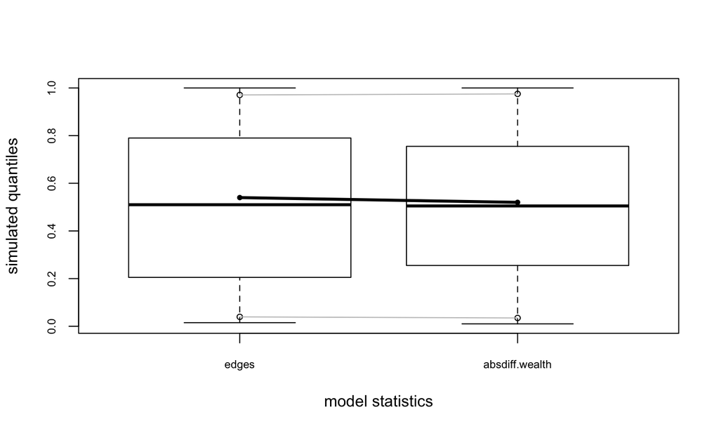

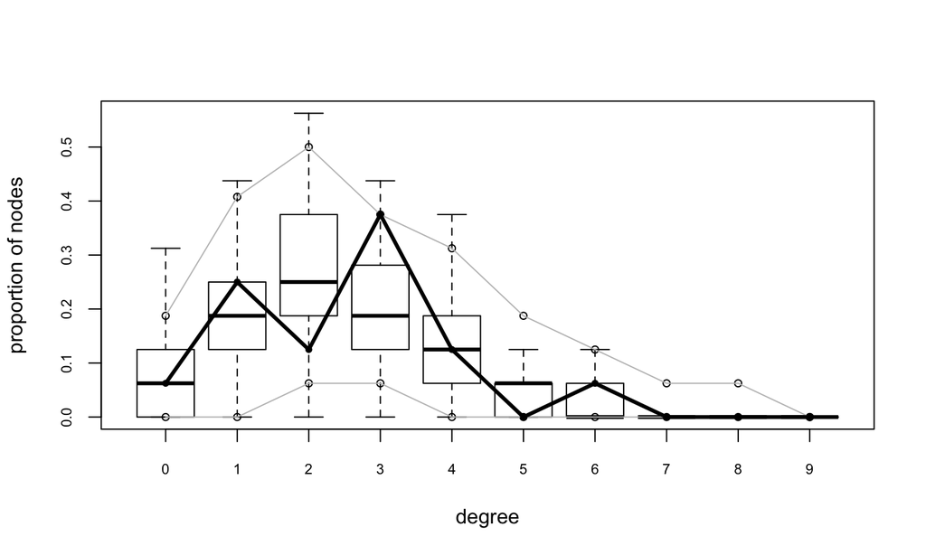

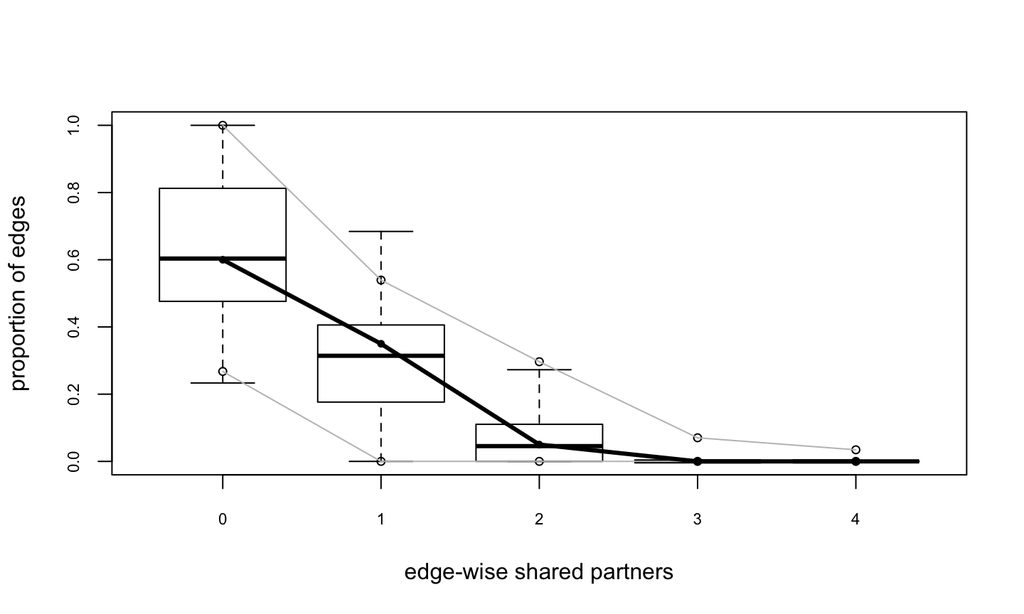

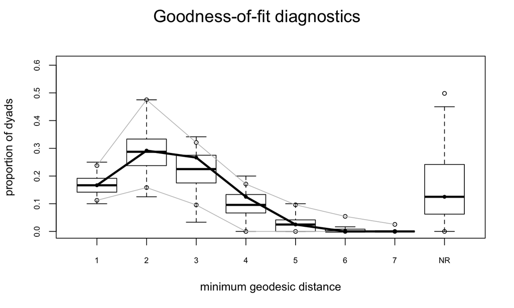

```r
#95% confidence interval
plot(flo.04.gof.model)
```

## `mcmc.diagnostics`

Check the MCMC

```r
#install.packages("latticeExtra")

fit <- ergm(flobusiness ~ edges+degree(1))
```

```
## Starting maximum pseudolikelihood estimation (MPLE):
```

```
## Evaluating the predictor and response matrix.
```

```
## Maximizing the pseudolikelihood.
```

```
## Finished MPLE.
```

```
## Starting Monte Carlo maximum likelihood estimation (MCMLE):
```

```
## Iteration 1 of at most 20:
```

```
## Optimizing with step length 1.
```

```
## The log-likelihood improved by 0.2425.
```

```
## Step length converged once. Increasing MCMC sample size.
```

```
## Iteration 2 of at most 20:
```

```
## Optimizing with step length 1.
```

```
## The log-likelihood improved by 0.001113.
```

```
## Step length converged twice. Stopping.
```

```
## Finished MCMLE.
```

```
## Evaluating log-likelihood at the estimate. Using 20 bridges: 1 2 3 4 5 6 7 8 9 10 11 12 13 14 15 16 17 18 19 20 .
## This model was fit using MCMC.  To examine model diagnostics and check for degeneracy, use the mcmc.diagnostics() function.
```

```r
mcmc.diagnostics(fit) #centered
```

```
## Sample statistics summary:
##
## Iterations = 16384:4209664
## Thinning interval = 1024
## Number of chains = 1
## Sample size per chain = 4096
##
## 1. Empirical mean and standard deviation for each variable,
##    plus standard error of the mean:
##
##             Mean    SD Naive SE Time-series SE
## edges   -0.12183 3.766  0.05884        0.05884
## degree1  0.07349 1.634  0.02553        0.02553
##
## 2. Quantiles for each variable:
##
##         2.5% 25% 50% 75% 97.5%
## edges     -7  -3   0   2     7
## degree1   -4  -1   0   1     3
##
##
## Sample statistics cross-correlations:
##           edges degree1
## edges    1.0000 -0.4341
## degree1 -0.4341  1.0000
##
## Sample statistics auto-correlation:
## Chain 1
##                 edges      degree1
## Lag 0     1.000000000  1.000000000
## Lag 1024  0.006760343  0.001466041
## Lag 2048  0.008602875 -0.006057681
## Lag 3072 -0.018218817 -0.011568388
## Lag 4096  0.028773889 -0.015764465
## Lag 5120 -0.015302900 -0.004412151
##
## Sample statistics burn-in diagnostic (Geweke):
## Chain 1
##
## Fraction in 1st window = 0.1
## Fraction in 2nd window = 0.5
##
##   edges degree1
##  0.9156 -0.5825
##
## Individual P-values (lower = worse):
##     edges   degree1
## 0.3598522 0.5602179
## Joint P-value (lower = worse):  0.6503828 .
```

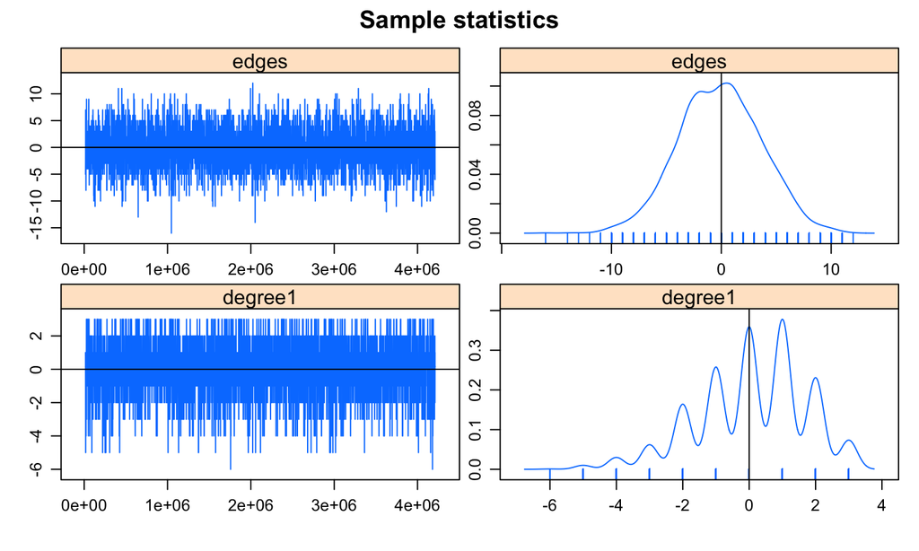

[output not shown]

## Interpretation on `mcmc.diagnostics`:

Good example.

- Mixing well: MCMC sample statistics are varying randomly around the observed values at each step
- Bell-shaped centered at 0. The difference between the observed and simulated values of the sample statistics have a roughly bell-shaped distribution, centered at 0.
- Notice the sawtooth pattern is due to the discrete values. The sawtooth pattern visible on the degree term deviation plot is due to the combination of discrete values and small range in the statistics: the observed number of degree 1 nodes is 3, and only a few discrete values are produced by the simulations.

Bad example:

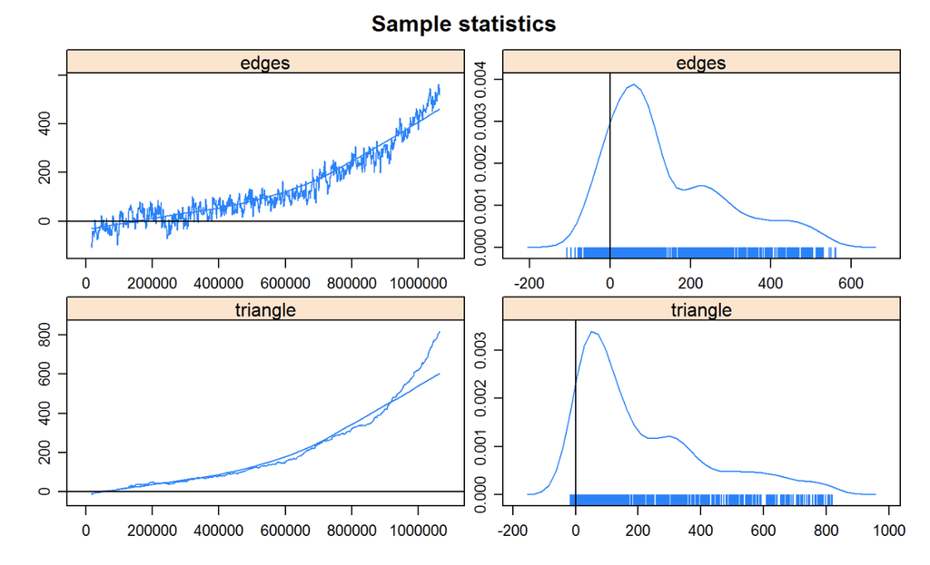

## More functions

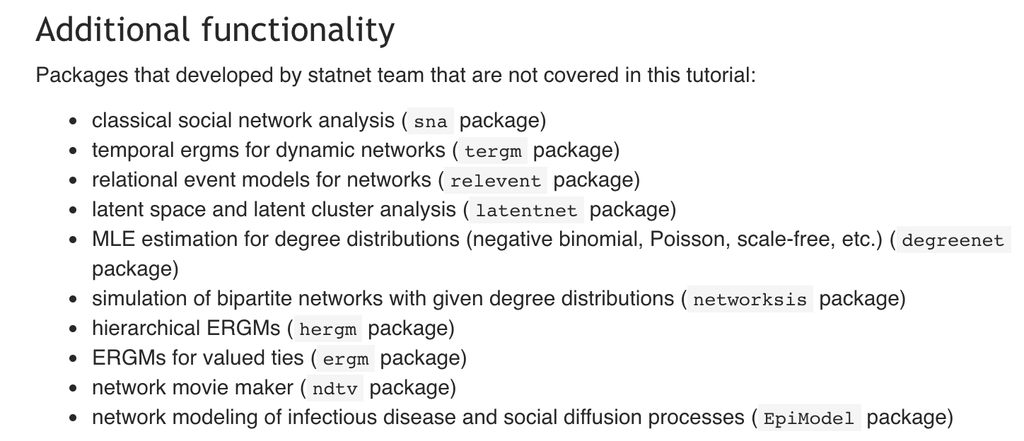